# ETC5521: Diving Deeply into Data Exploration

Initial data analysis and model diagnostics

Professor Di Cook

Department of Econometrics and Business Statistics

## The role of initial data analysis

*The first thing to do with data is to look at them …. usually means tabulating and plotting the data in many different ways to see what’s going on. With the wide availability of computer packages and graphics nowadays there is no excuse for ducking the labour of this preliminary phase, and it may save some* **red faces** *later.*

[Crowder, M. J. & Hand, D. J. (1990) “Analysis of Repeated Measures”](https://doi.org/10.1201/9781315137421)

## Initial Data Analysis

Prior to conducting a confirmatory data analysis, it is important to conduct an *initial data analysis (IDA)*.

- Confirmatory data analysis (CDA) is focused on statistical inference and includes procedures for:
  - hypothesis testing,
  - predictive modelling,
  - parameter estimation including uncertainty,
  - model selection.
- IDA includes:
  - describing the data and collection procedures
  - scrutinise data for errors, outliers, missing observations
  - check assumptions for confirmatory data analysis

IDA is sometimes called preliminary data analysis.

IDA is related to exploratory data analysis (EDA) in the sense that it is primarily conducted graphically, and there are few formal tests available.

## Model diagnostics

After to conducting a confirmatory data analysis, it is important to *check the results*.

- Model diagnostics (MD) check that the result is fit for making inference:
  - fit statistics, including error
  - residual plots
  - multicollinearity checks
  - influence statistics
  - feature importance
  - not overfitting
- It may lead to, re-ftting after:
  - removing variables and/or observations
  - transforming variables
  - changing the type of model

MD is related to exploratory data analysis (EDA) in the sense that it also depends on graphical summaries.

## Objectives of IDA?

The **main objective for IDA** is to intercept any problems in the data that might adversely affect the confirmatory data analysis.

- The role of **CDA** is to answer the intended question(s) that the data were collected for.
- *IDA is often unreported* in the data analysis reports or scientific papers, for various reasons. It might not have been done, or it may have been conducted but there was no space in the paper to report on it.

## IDA in government statistics

The purpose of data cleaning is to bring data up to a level of quality such that it can reliably be used for the production of statistical models or statements.

A statistical value chain is constructed by defining a number of meaningful intermediate data products, for which a chosen set of quality attributes are well described.

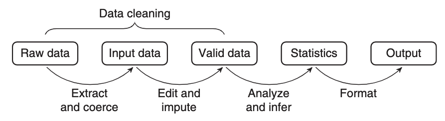

van der Loo & de Jonge (2018) Statistical Data Cleaning with Applications in R

## IDA in health and medical data

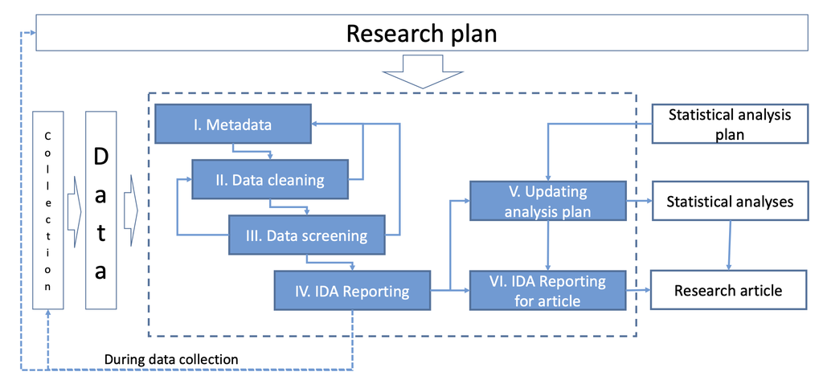

Huebner et al (2018)’s six steps of IDA: (1) Metadata setup, (2) Data cleaning, (3) Data screening, (4) Initial reporting, (5) Refining and updating the analysis plan, (6) Reporting IDA in documentation.

## Heed these words

IDA prepares the data for CDA. One needs to be careful about NOT compromising the inference.

How do you compromise inference?

1. Change your inference or questions based on what you find in IDA.
2. Outlier removal or not.
3. Missing value imputation choices.
4. Treatment of zeros.
5. Handling of variable type, categorical temporal.
6. Lack of multivariate relationship checking, including subsets based on levels of categorical variables.
7. Choosing variables and observations.

How do you avoid these errors?

- Document ALL the IDA, using a reproducible analysis script.
- Pre-register your CDA plan, so that your CDA questions do not change.
- Decisions made on outlier removal, variable selection, recoding, sampling, handling of zeros have known affects on results, and are justifiable.

Insure yourself against accusations of data snooping, data dredging, data fishing, data leakage.

## Data screening

## Data screening

It’s important to check how the data are understood by the computer.

that is, checking for *data type*:

- Was the date read in as character?
- Was a factor read in as numeric?

## Example: Checking the data type (1/2)

`lecture3-example.xlsx`

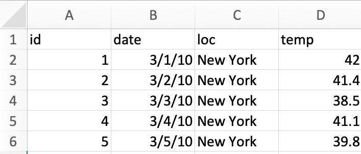

```r
library(readxl)
library(here)
df <- read_excel(here("data/lecture3-example.xlsx"))
df
```

```
# A tibble: 5 × 4
     id date                loc       temp
  <dbl> <dttm>              <chr>    <dbl>
1     1 2010-01-03 00:00:00 New York  42
2     2 2010-02-03 00:00:00 New York  41.4
3     3 2010-03-03 00:00:00 New York  38.5
4     4 2010-04-03 00:00:00 New York  41.1
5     5 2010-05-03 00:00:00 New York  39.8
```

- What problems are there with the computer’s interpretation of data type?
- What context specific issues indicate incorrect computer interpretation?

## Example: Checking the data type (2/2)

```r
library(lubridate)
df <- read_excel(here("data/lecture3-example.xlsx"),
                 col_types = c("text",
                               "date",
                               "text",
                               "numeric"))

df |>
  mutate(id = as.factor(id),
         date = ydm(date)) |>
  mutate(
         day = day(date),
         month = month(date),
         year = year(date))
```

```
# A tibble: 5 × 7
  id    date       loc       temp   day month  year
  <fct> <date>     <chr>    <dbl> <int> <dbl> <dbl>
1 1     2010-03-01 New York  42       1     3  2010
2 2     2010-03-02 New York  41.4     2     3  2010
3 3     2010-03-03 New York  38.5     3     3  2010
4 4     2010-03-04 New York  41.1     4     3  2010
5 5     2010-03-05 New York  39.8     5     3  2010
```

- `id` is now a `factor` instead of `integer`
- `day`, `month` and `year` are now extracted from the `date`
- Is it okay now?
- In the United States, it’s common to use the date format MM/DD/YYYY [(gasps)](https://twitter.com/statsgen/status/1257959369448161281) while the rest of the world commonly uses DD/MM/YYYY or better still YYYY/MM/DD.
- It’s highly probable that the dates are 1st-5th March and not 3rd of Jan-May.
- You can validate interpretation of temperature using [weather database](https://www.wunderground.com/history/monthly/us/ny/new-york-city/KLGA/date/2010-3).

## Example: Specifying the data type with R

- You can robustify your workflow by ensuring you have a check for the expected data type in your code.

```r
xlsx_df <- read_excel(here("data/lecture3-example.xlsx"),
                 col_types = c("text", "date", "text", "numeric"))  |>
  mutate(id = as.factor(id),
         date = as.character(date),
         date = as.Date(date, format = "%Y-%d-%m"))
```

- `read_csv` has a broader support for `col_types`

```r
csv_df <- read_csv(here::here("data/lecture3-example.csv"),
                 col_types = cols(
                      id = col_factor(),
                      date = col_date(format = "%m/%d/%y"),
                      loc = col_character(),
                      temp = col_double()))
```

- The checks (or coercions) ensure that even if the data are updated, you can have some confidence that any data type error will be picked up before further analysis.

## Example: Checking the data type with R

You can have a quick glimpse of the data type with:

```r
dplyr::glimpse(xlsx_df)
```

```
Rows: 5
Columns: 4
$ id   <fct> 1, 2, 3, 4, 5
$ date <date> 2010-03-01, 2010-03-02, 2010-03-03, 2010-03-0…
$ loc  <chr> "New York", "New York", "New York", "New Yor…
$ temp <dbl> 42, 41, 38, 41, 40
```

```r
dplyr::glimpse(csv_df)
```

```
Rows: 5
Columns: 4
$ id   <fct> 1, 2, 3, 4, 5
$ date <date> 2010-03-01, 2010-03-02, 2010-03-03, 2010-03-0…
$ loc  <chr> "New York", "New York", "New York", "New Yor…
$ temp <dbl> 42, 41, 38, 41, 40
```

## Example: Checking the data type visually

You can also visualise the data type with:

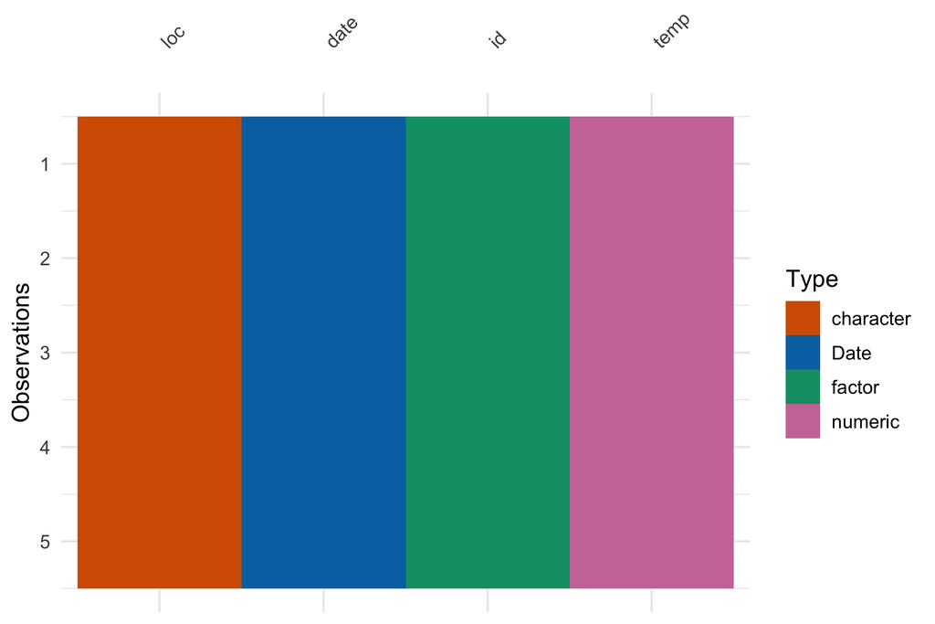

```r
library(visdat)
vis_dat(xlsx_df)
```

## Your turn: spot the type problems

A colleague sends you `lecture3-example2.csv`, an extension of the weather example with a few more rows.

**Your turn**

1. Read the file in with `read_csv()` and `glimpse()` it – don’t specify `col_types` yet.
2. What does R guess for each column’s type? Is it right?
3. Look closely at the `date` column: the file mixes dates from two different decades. What ambiguity does that create?
4. Is there anything else worth flagging (e.g. missing values)?
- Check in R
- Data
- Explanation

```r
ex2 <- read_csv(here::here("data/lecture3-example2.csv"))
glimpse(ex2)
```

```
Rows: 9
Columns: 4
$ id   <dbl> 1, 2, 3, 4, 5, 6, 7, 8, 9
$ date <chr> "3/1/10", "3/2/10", "3/3/10", "3/4/10", "3/5/…
$ loc  <chr> "New York", "New York", "New York", "New York…
$ temp <dbl> 42, 41, 38, 41, 40, 31, 18, 19, 21
```

The `loc` value is missing for one row, and `date` mixes “3/1/10” and “3/1/20” – is that a two-digit year of 2010 vs 2020, or March 1 read a different way? Two-digit years are always worth double-checking.

## Data cleaning

## Data cleaning

Data quality checks should be one of the first steps in the data analysis to *assess any problems with the data*.

These include using common or domain knowledge to check if the recorded data have sensible values.

- Are positive values, e.g. height and weight, recorded as positive values with a plausible range?
- If the data are counts, do the recorded values contain non-integer values?
- For compositional data, do the values add up to 100% (or 1)? If not, is that a measurement error or due to rounding? Or is another variable missing?
- Does the data contain only positives, ie disease occurrences, or warranty claims? If so, what would the no report group look like?

## Case study: World development indicators (1/7)

```r
options(width=80)
raw_dat <- read_csv(here("data/world-development-indicators.csv"),
                    na = "..", n_max = 11935)
glimpse(raw_dat)
```

```
Rows: 11,935
Columns: 54
$ `Country Name`  <chr> "Argentina", "Argentina", "Argentina", "Argentina", "A…
$ `Country Code`  <chr> "ARG", "ARG", "ARG", "ARG", "ARG", "ARG", "ARG", "ARG"…
$ `Series Name`   <chr> "Adolescent fertility rate (births per 1,000 women age…
$ `Series Code`   <chr> "SP.ADO.TFRT", "NV.AGR.TOTL.ZS", "ER.H2O.FWTL.ZS", "SH…
$ `1969 [YR1969]` <dbl> 6.4e+01, 9.2e+00, NA, NA, 3.3e+00, NA, 2.2e+01, NA, NA…
$ `1970 [YR1970]` <dbl> 6.5e+01, 9.6e+00, NA, NA, 3.5e+00, NA, 2.5e+01, NA, NA…
$ `1971 [YR1971]` <dbl> 6.7e+01, 1.1e+01, NA, NA, 3.7e+00, NA, 2.4e+01, 8.7e+0…
$ `1972 [YR1972]` <dbl> 6.8e+01, 1.1e+01, NA, NA, 3.6e+00, NA, 1.9e+01, 9.2e+0…
$ `1973 [YR1973]` <dbl> 7.1e+01, 1.2e+01, NA, NA, 3.7e+00, NA, 2.7e+01, 9.6e+0…
$ `1974 [YR1974]` <dbl> 7.5e+01, 1.0e+01, NA, NA, 3.7e+00, NA, 3.0e+01, 9.9e+0…
$ `1975 [YR1975]` <dbl> 7.8e+01, 6.6e+00, NA, NA, 3.6e+00, NA, 2.9e+01, 1.0e+0…
$ `1976 [YR1976]` <dbl> 8.1e+01, 8.2e+00, NA, NA, 3.8e+00, NA, 2.0e+01, 1.0e+0…
$ `1977 [YR1977]` <dbl> 8.4e+01, 8.1e+00, 9.5e+00, NA, 3.7e+00, NA, 2.6e+01, 1…
```

[output cut: 41 more lines]

World Development Indicators (WDI), sourced from the [World Bank Group (2019)](https://databank.worldbank.org/source/world-development-indicators/)

- What are the data types?
- What are the variables?
- What are the observations?
- Is the data in tidy form?

## Case study: World development indicators (2/7)

```r
country_code_df <- raw_dat  |>
  distinct(`Country Name`, `Country Code`)  |>
  rename_all(janitor::make_clean_names)  |>
  left_join(
    countrycode::codelist |> select(iso3c, region, continent),
    by = c("country_code" = "iso3c")
  )  |>
  arrange(continent, region)
```

```r
options(width=80)
glimpse(country_code_df)
```

```
Rows: 217
Columns: 4
$ country_name <chr> "Algeria", "Djibouti", "Egypt, Arab Rep.", "Libya", "Moro…
$ country_code <chr> "DZA", "DJI", "EGY", "LBY", "MAR", "TUN", "AGO", "BEN", "…
$ region       <chr> "Middle East & North Africa", "Middle East & North Africa…
$ continent    <chr> "Africa", "Africa", "Africa", "Africa", "Africa", "Africa…
```

```r
country_code_df |> count(continent)
```

```
# A tibble: 6 × 2
  continent     n
  <chr>     <int>
1 Africa       54
2 Americas     46
3 Asia         50
4 Europe       46
5 Oceania      19
6 <NA>          2
```

```r
country_code_df |> count(region)
```

```
# A tibble: 8 × 2
  region                         n
  <chr>                      <int>
1 East Asia & Pacific           37
2 Europe & Central Asia         56
3 Latin America & Caribbean     41
4 Middle East & North Africa    21
5 North America                  3
6 South Asia                     8
7 Sub-Saharan Africa            48
8 <NA>                           3
```

- How many countries are included
- How many continents, regions?
- Why are there NAs here?

```r
country_code_df |> filter(is.na(continent))
```

```
# A tibble: 2 × 4
  country_name    country_code region continent
  <chr>           <chr>        <chr>  <chr>
1 Channel Islands CHI          <NA>   <NA>
2 Kosovo          XKX          <NA>   <NA>
```

## Case study: World development indicators (3/7)

```r
wdi_vars <- raw_dat  |>
  select(`Series Name`, `Series Code`) |>
  distinct() |>
  rename_all(janitor::make_clean_names)
```

```r
wdi_vars |> gt::gt()
```

| series_name | series_code |
| --- | --- |
| Adolescent fertility rate (births per 1,000 women ages 15-19) | SP.ADO.TFRT |
| Agriculture, forestry, and fishing, value added (% of GDP) | NV.AGR.TOTL.ZS |
| Annual freshwater withdrawals, total (% of internal resources) | ER.H2O.FWTL.ZS |
| Births attended by skilled health staff (% of total) | SH.STA.BRTC.ZS |
| CO2 emissions (metric tons per capita) | EN.ATM.CO2E.PC |
| Contraceptive prevalence, any methods (% of women ages 15-49) | SP.DYN.CONU.ZS |
| Domestic credit provided by financial sector (% of GDP) | FS.AST.DOMS.GD.ZS |
| Electric power consumption (kWh per capita) | EG.USE.ELEC.KH.PC |
| Energy use (kg of oil equivalent per capita) | EG.USE.PCAP.KG.OE |
| Exports of goods and services (% of GDP) | NE.EXP.GNFS.ZS |
| External debt stocks, total (DOD, current US$) | DT.DOD.DECT.CD |
| Fertility rate, total (births per woman) | SP.DYN.TFRT.IN |
| Foreign direct investment, net inflows (BoP, current US$) | BX.KLT.DINV.CD.WD |
| Forest area (sq. km) | AG.LND.FRST.K2 |
| GDP (current US$) | NY.GDP.MKTP.CD |
| GDP growth (annual %) | NY.GDP.MKTP.KD.ZG |
| GNI per capita, Atlas method (current US$) | NY.GNP.PCAP.CD |
| GNI per capita, PPP (current international $) | NY.GNP.PCAP.PP.CD |
| GNI, Atlas method (current US$) | NY.GNP.ATLS.CD |
| GNI, PPP (current international $) | NY.GNP.MKTP.PP.CD |
| Gross capital formation (% of GDP) | NE.GDI.TOTL.ZS |
| High-technology exports (% of manufactured exports) | TX.VAL.TECH.MF.ZS |
| Immunization, measles (% of children ages 12-23 months) | SH.IMM.MEAS |
| Imports of goods and services (% of GDP) | NE.IMP.GNFS.ZS |
| Income share held by lowest 20% | SI.DST.FRST.20 |
| Industry (including construction), value added (% of GDP) | NV.IND.TOTL.ZS |
| Inflation, GDP deflator (annual %) | NY.GDP.DEFL.KD.ZG |
| Life expectancy at birth, total (years) | SP.DYN.LE00.IN |
| Merchandise trade (% of GDP) | TG.VAL.TOTL.GD.ZS |
| Military expenditure (% of GDP) | MS.MIL.XPND.GD.ZS |
| Mobile cellular subscriptions (per 100 people) | IT.CEL.SETS.P2 |
| Mortality rate, under-5 (per 1,000 live births) | SH.DYN.MORT |
| Net barter terms of trade index (2000 = 100) | TT.PRI.MRCH.XD.WD |
| Net migration | SM.POP.NETM |
| Net official development assistance and official aid received (current US$) | DT.ODA.ALLD.CD |
| Personal remittances, received (current US$) | BX.TRF.PWKR.CD.DT |
| Population density (people per sq. km of land area) | EN.POP.DNST |
| Population growth (annual %) | SP.POP.GROW |
| Population, total | SP.POP.TOTL |
| Poverty headcount ratio at $1.90 a day (2011 PPP) (% of population) | SI.POV.DDAY |
| Poverty headcount ratio at national poverty lines (% of population) | SI.POV.NAHC |
| Prevalence of HIV, total (% of population ages 15-49) | SH.DYN.AIDS.ZS |
| Prevalence of underweight, weight for age (% of children under 5) | SH.STA.MALN.ZS |
| Primary completion rate, total (% of relevant age group) | SE.PRM.CMPT.ZS |
| Revenue, excluding grants (% of GDP) | GC.REV.XGRT.GD.ZS |
| School enrollment, primary (% gross) | SE.PRM.ENRR |
| School enrollment, primary and secondary (gross), gender parity index (GPI) | SE.ENR.PRSC.FM.ZS |
| School enrollment, secondary (% gross) | SE.SEC.ENRR |
| Statistical Capacity score (Overall average) | IQ.SCI.OVRL |
| Surface area (sq. km) | AG.SRF.TOTL.K2 |
| Tax revenue (% of GDP) | GC.TAX.TOTL.GD.ZS |
| Terrestrial and marine protected areas (% of total territorial area) | ER.PTD.TOTL.ZS |
| Time required to start a business (days) | IC.REG.DURS |
| Total debt service (% of exports of goods, services and primary income) | DT.TDS.DECT.EX.ZS |
| Urban population growth (annual %) | SP.URB.GROW |

- Analysis will use the short name (`series_code`) for variables.
- Store full variable name (`series_name`) and short name (`series_code`) in a separate table.
- The `series_code` will be used as the key whenever the full name is needed.

## Case study: World development indicators (4/7)

```r
wdi <- raw_dat  |>
  select(`Country Code`, `Series Code`, `1969 [YR1969]`:`2018 [YR2018]`) |>
  rename_all(janitor::make_clean_names) |>
  pivot_longer(x1969_yr1969:x2018_yr2018,
               names_to = "year",
               values_to = "value") |>
  mutate(year = as.numeric(str_sub(year, 2, 5)) ) |>
  pivot_wider(names_from = series_code,
              values_from = value)

wdi2017 <- wdi  |> filter(year == 2017)
```

- Organise data into tidy form
- Check missing value distribution

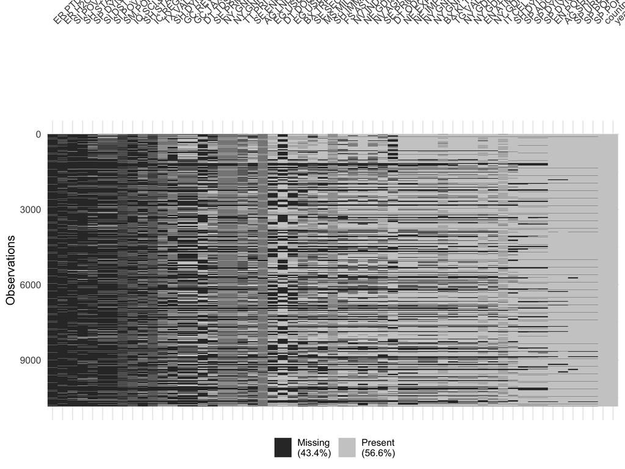

```r
vis_miss(wdi, sort_miss = TRUE)
```

## Case study: World development indicators (5/7)

Check missings by

- variable
- country

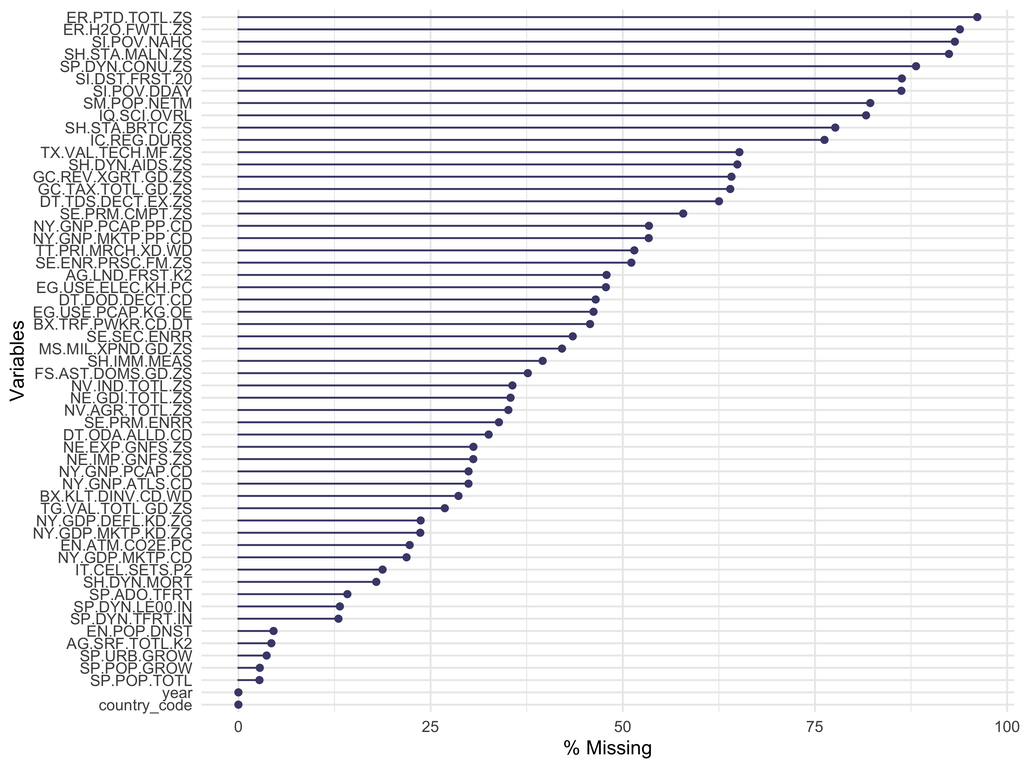

```r
gg_miss_var(wdi, show_pct=TRUE)
```

```r
wdi_cnt_miss <- wdi |>
  filter(!is.na(country_code)) |>
  bind_shadow() |>
  select(country_code, year,
         SP.ADO.TFRT_NA:SP.URB.GROW_NA) |>
  pivot_longer(SP.ADO.TFRT_NA:SP.URB.GROW_NA,
               names_to="var",
               values_to="value") |>
  group_by(country_code) |>
  count(value) |>
  mutate(value = fct_recode(value,
                            miss="NA",
                            not="!NA")) |>
  pivot_wider(names_from = value, values_from = n) |>
  mutate(p_miss = miss/(miss+not)) |>
  select(country_code, p_miss)
wdi_cnt_p <- wdi_cnt_miss |>
  ggplot(aes(x=1, y=p_miss,
             label=country_code)) +
  geom_quasirandom() +
  ylim(c(0,1)) + ylab("Prop miss")
ggplotly(wdi_cnt_p)
```

[interactive chart not shown]

## Case study: World development indicators (6/7)

Look at Costa Rica (CRI), most complete country

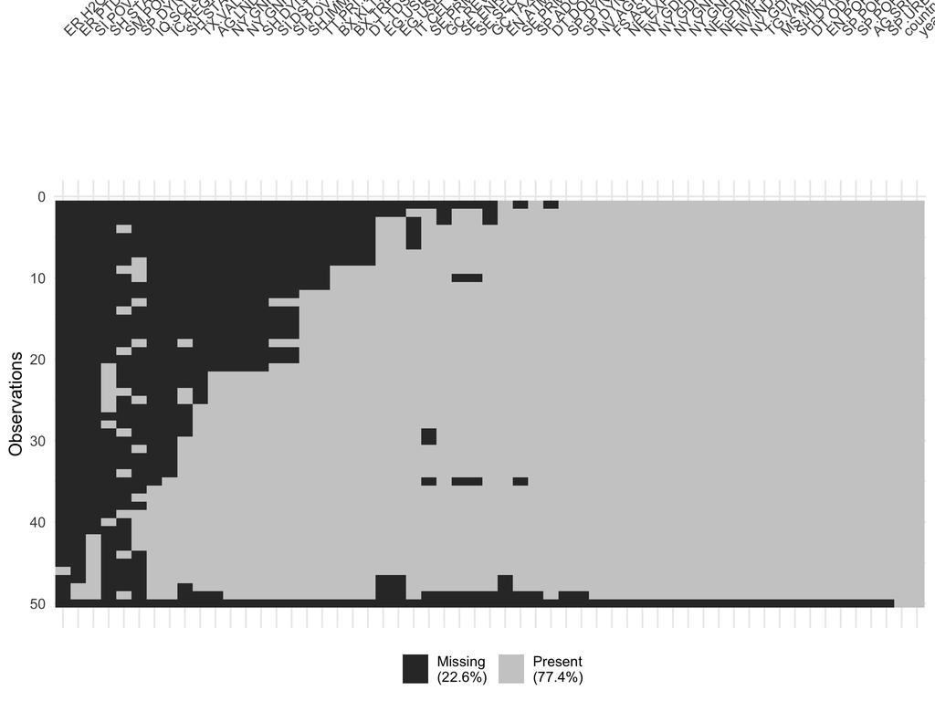

```r
wdi_cri <- wdi |>
  filter(country_code == "CRI")
vis_miss(wdi_cri, sort_miss=TRUE)
```

To illustrate imputation, we’ll show one of the variables, that is relatively complete.

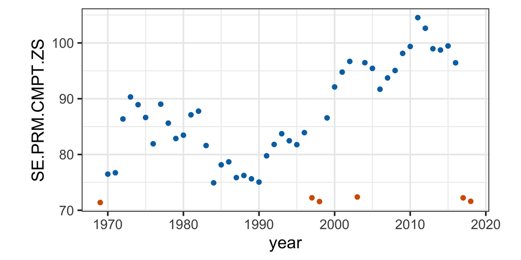

```r
wdi_cri_p <- wdi_cri |>
  ggplot(aes(x=year, y=SE.PRM.CMPT.ZS)) +
  geom_miss_point() +
  theme(aspect.ratio=0.5,
        legend.position = "none")
wdi_cri_p
```

## Case study: World development indicators (6/7)

Missings imputed using `imputeTS` using the moving average method.

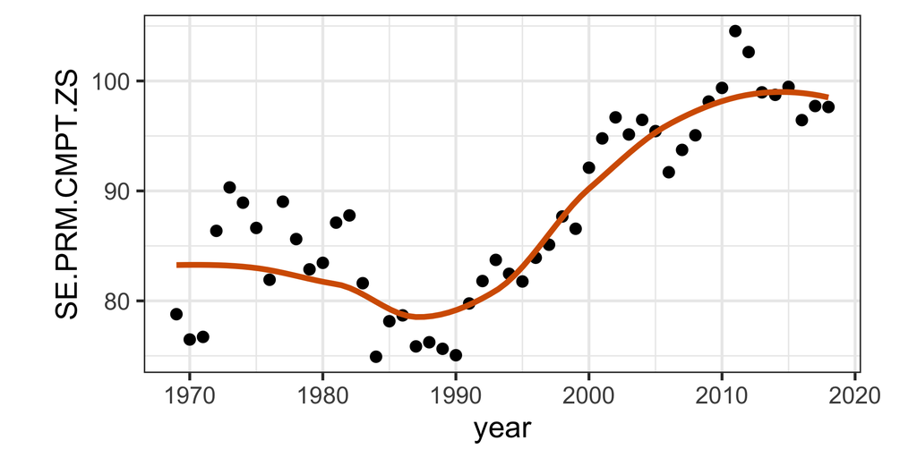

```r
library(imputeTS)

wdi_cri_v1 <- wdi_cri |>
  mutate(SE.PRM.CMPT.ZS = na_ma(SE.PRM.CMPT.ZS))

wdi_cri_v1  |>
  ggplot(aes(x=year, y=SE.PRM.CMPT.ZS)) +
  geom_point() +
  geom_smooth(se=F, colour="#D55E00") +
  theme(aspect.ratio=0.5)
```

- Don’t have to impute before scrutinizing data
- What are these numbers supposed to be?

`SE.PRM.CMPT.ZS` is “Primary completion rate, total (% of relevant age group)”

Do we have any problems?

Yes. The explanation of the variable suggests the numbers should range between 0-100.

## Your turn: check another country

**Your turn**

1. Pick a different `country_code` from `wdi` (not `"CRI"`).
2. Produce a `vis_miss()` plot for that country, sorted by missingness.
3. Is it more or less complete than Costa Rica? Would you be comfortable imputing missing values for it?
- Check in R
- Australia

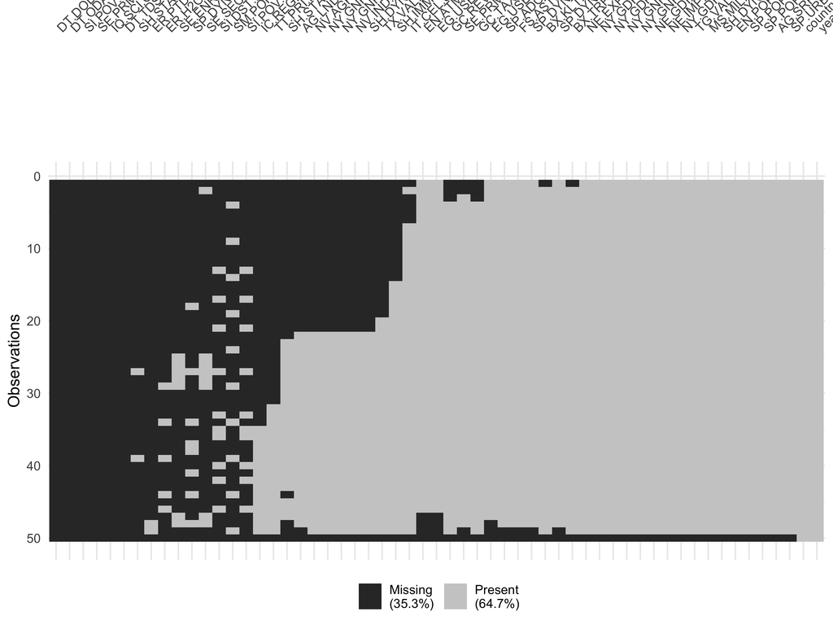

```r
wdi |>
  filter(country_code == "AUS") |>
  vis_miss(sort_miss = TRUE)
```

## 📋 Summary of the process

The steps we took roughly followed these:

```r
DiagrammeR::grViz("digraph {
  graph [layout = circo, rankdir = TB]

  node [shape = rectangle,
  fontname = 'Helvetica']
  rec1 [label = 'Input data',
  fontname = 'Helvetica']
  rec2 [label = 'Tidy data',
  fontname = 'Helvetica']
  rec3 [label = 'Data screening',
  fontname = 'Helvetica']
  rec4 [label = 'Data cleaning',
  fontname = 'Helvetica']
  rec5 [label = 'Impute missings',
  fontname = 'Helvetica']
  rec6 [label = 'Valid data',
  fontname = 'Helvetica']

  # edge definitions with the node IDs
  rec1 -> rec2 -> rec3 -> rec4 -> rec5
  rec5 -> rec3
  rec3 -> rec6
  }",
  height = 300,
  width = 500
  )
```

[interactive chart not shown]

At the end of this stage we would have:

- 3 tables of data: country name/code, variables name/key, time series of multiple variables for many countries
- What would you like to learn from this data? What sort of models might be fitted? What types of hypotheses might be tested?
- Have we done anything that might have compromised the later analysis?

## Data collection

## Case study: Employment Data in Australia (1/3)

```r
# Note: because this downloads data
# run it once, and save the result so
# data server isn't overloaded
library(readabs)
employed <- read_abs(series_id = "A84423085A")  |>
  mutate(month = lubridate::month(date),
         year = lubridate::year(date))  |>
  #filter(year != "2020")  |>
  select(date, month, year, value)
save(employed, file="../data/employed.rda")
```

```r
load(here::here("data/employed.rda"))

glimpse(employed)
```

```
Rows: 557
Columns: 4
$ date  <date> 1978-02-01, 1978-03-01, 1978-04-01, 1978-05-01, 1978-06-01, 197…
$ month <dbl> 2, 3, 4, 5, 6, 7, 8, 9, 10, 11, 12, 1, 2, 3, 4, 5, 6, 7, 8, 9, 1…
$ year  <dbl> 1978, 1978, 1978, 1978, 1978, 1978, 1978, 1978, 1978, 1978, 1978…
$ value <dbl> 5986, 6041, 6054, 6038, 6031, 6036, 6005, 6024, 6046, 6034, 6125…
```

Australian Bureau of Statistics, Labour force, Australia, [Table 01](https://www.abs.gov.au/AUSSTATS/abs@.nsf/DetailsPage/6202.0Jul%202020?OpenDocument). Labour force status by Sex, Australia - Trend, Seasonally adjusted and Original

## Case study: Employment Data in Australia (2/3)

What do you notice?

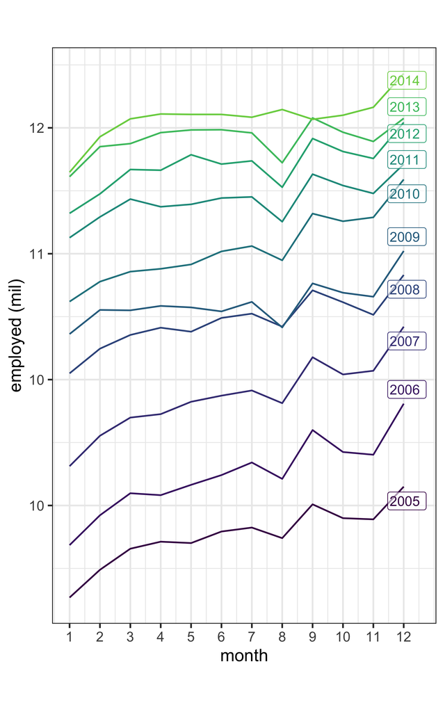

```r
employed_2000 <- employed |>
  filter(between(year, 2005, 2014)) |>
  mutate(year = factor(year)) |>
  ungroup()
labels_2000 <- employed_2000 |>
  group_by(year) |>
  slice_tail(n = 1) |>
  ungroup()

ggplot() +
  geom_line(data = employed_2000,
    aes(x = month, y = value/1000, color = year)) +
  geom_label_repel(
    data = labels_2000,
    aes(x = month, y = value/1000,
        label = year, color = year),
    fill = alpha("white", 0.6),
    direction = "y",
    hjust = 0,
    nudge_x = 0.5,
    segment.color = "grey70"
  ) +
  ylab("employed (mil)") +
  scale_x_continuous("month", breaks=seq(1, 12, 1)) +
  scale_color_viridis_d("", end = 0.8) +
  theme(aspect.ratio = 1.5,
        legend.position = "none")
```

Why do you think the number of people employed is going up each year?

- Australian population is **25.39 million** in 2019
- 1.5% annual increase in population
- Vic population is 6.681 million (Sep 2020) - 26%
- NSW population is 8.166 (Sep 2020) - 32%

## Case study: Employment Data in Australia (3/3)

- Also notice a change in August numbers from 2014.

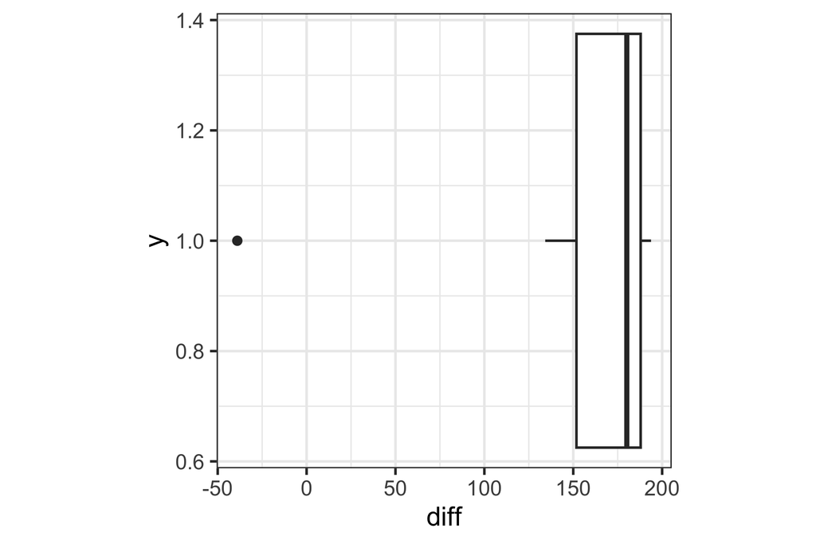

```r
employed_2000  |>
  filter(month %in% 8:9)  |>
  pivot_wider(id_cols = year,
    names_from = month)  |>
  mutate(diff = `9` - `8`)  |>
  ggplot(aes(x = diff, y = 1)) +
  geom_boxplot()
```

- A potential explanation for this is that there was a *change in the survey from 2014*.

See discussion on this at [Hyndsight blog (10 October 2014)](https://robjhyndman.com/hyndsight/abs-seasonal-adjustment-2/).

## Your turn: check other month pairs

How do we provide evidence that the August-to-September is a genuine problem, that is worth investigating to understand why.

**Your turn**

1. Repeat the same check for each consecutive different pair of adjacent months (e.g. June to July).
2. Make the boxplots for each set of differences. You can plot them against month, or use facetting.
3. Does the same kind of step-change show up?
4. What does this tell you about whether the August/September pattern is a specific, real event, versus something you’d see between any two months?
- Check in R
- Code
- Plot

```r
employed_diffs <- employed_2000 |>
  arrange(date) |>
  mutate(diff = value - dplyr::lag(value)) |>
  mutate(month_c = factor(month, levels = c(1:12),
    labels = c("jan", "feb", "mar", "apr", "may", "jun", "jul", "aug", "sep", "oct", "nov", "dec"))) |>
  group_by(month_c) |>
  mutate(diff_m = diff -
    median(diff, na.rm = TRUE)) |>
  ungroup()
```

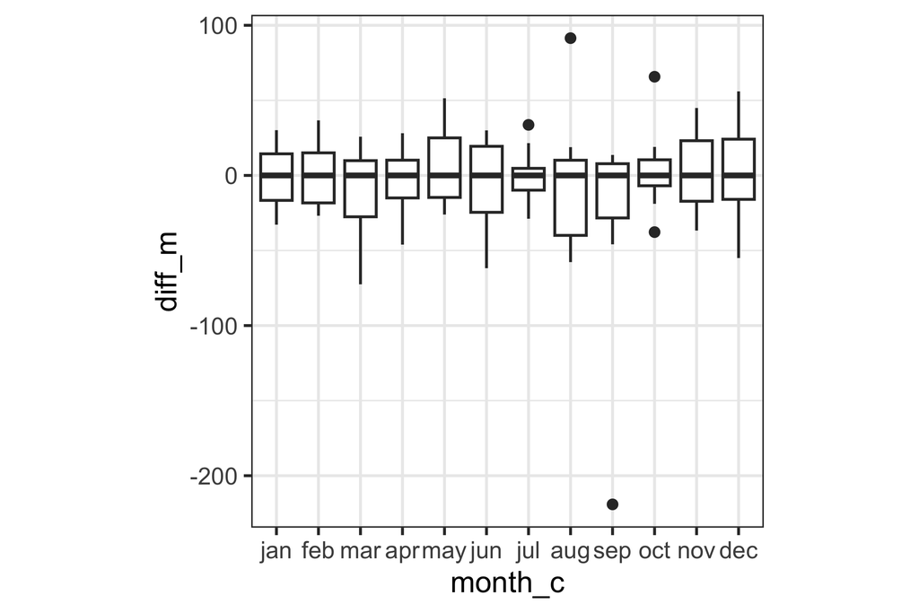

```r
employed_diffs |>
  filter(!is.na(diff)) |>
  ggplot(aes(x = month_c, y = diff_m)) +
    geom_boxplot()
```

## Case study: 2014 Data Mining Cup winners

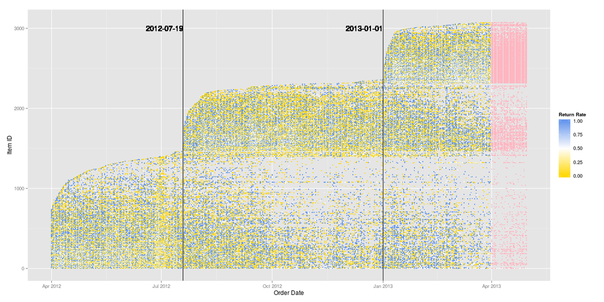

Ugly plot of all observations provided in training sample, with response variable in colour, and test sample to predict.

What does this tell you about the test sample?

## Case study: french fries/hot chips (1/2)

```r
options(width=50)
load(here::here("data/french_fries.rda"))
glimpse(french_fries)
```

```
Rows: 696
Columns: 9
$ time      <fct> 1, 1, 1, 1, 1, 1, 1, 1, 1, 1, …
$ treatment <fct> 1, 1, 1, 1, 1, 1, 1, 1, 1, 1, …
$ subject   <fct> 3, 3, 10, 10, 15, 15, 16, 16, …
$ rep       <dbl> 1, 2, 1, 2, 1, 2, 1, 2, 1, 2, …
$ potato    <dbl> 2.9, 14.0, 11.0, 9.9, 1.2, 8.8…
$ buttery   <dbl> 0.0, 0.0, 6.4, 5.9, 0.1, 3.0, …
$ grassy    <dbl> 0.0, 0.0, 0.0, 2.9, 0.0, 3.6, …
$ rancid    <dbl> 0.0, 1.1, 0.0, 2.2, 1.1, 1.5, …
$ painty    <dbl> 5.5, 0.0, 0.0, 0.0, 5.1, 2.3, …
```

10 week sensory experiment, 12 individuals assessed taste of french fries on several scales (how potato-y, buttery, grassy, rancid, paint-y do they taste?), fried in one of 3 different oils, replicated twice.

- Is the design complete?
- Are replicates like each other?
- How do the ratings on the different scales differ?
- Are raters giving different scores on average?
- Do ratings change over the weeks?

## Case study: french fries/hot chips (2/2)

- Is the design complete?

```r
french_fries |> count(subject)
```

```
# A tibble: 12 × 2
   subject     n
   <fct>   <int>
 1 3          54
 2 10         60
 3 15         60
 4 16         60
 5 19         60
 6 31         54
 7 51         60
 8 52         60
 9 63         60
10 78         60
11 79         54
12 86         54
```

```r
french_fries |> count(time)
```

```
# A tibble: 10 × 2
   time      n
   <fct> <int>
 1 1        72
 2 2        72
 3 3        72
 4 4        72
 5 5        72
 6 6        72
 7 7        72
 8 8        72
 9 9        60
10 10       60
```

```r
french_fries |> count(treatment)
```

```
# A tibble: 3 × 2
  treatment     n
  <fct>     <int>
1 1           232
2 2           232
3 3           232
```

```r
french_fries |> count(rep)
```

```
# A tibble: 2 × 2
    rep     n
  <dbl> <int>
1     1   348
2     2   348
```

## Your turn: is this design complete?

`lecture3-example3.csv` is a small field trial: yield measured on plots in a `row` x `col` grid, under different `trt` (treatment) and `block`.

**Your turn**

1. Read in the data and cross-tabulate `trt` against `block` (e.g. with `count()`).
2. Is every treatment applied in every block the same number of times?
3. If not, which treatment(s) are over- or under-represented, and how might that affect comparisons between treatments?
- Check in R
- Code
- Answer

```r
field <- read_csv(here::here("data/lecture3-example3.csv"))
field |>
  count(trt, block) |>
  pivot_wider(names_from = block, values_from = n)
```

```
# A tibble: 9 × 5
  trt         B1    B2    B3    B4
  <chr>    <int> <int> <int> <int>
1 hi dust      1     1     1     1
2 hi manu      1     1     1     1
3 hi soot      1     1     1     1
4 hi sulph     1     1     1     1
5 lo manu      1     1     1     1
6 lo soot      1     1     1     1
7 lo sulph     1     1     1     1
8 low dust     1     1     1     1
9 none         4     4     4     4
```

The `"none"` treatment appears 4 times per block, while every other treatment appears only once – an unbalanced design.

## Case study: Warranty claims

```r
warranty <- read_csv(here("data/warranty-kaggle.csv"))
warranty |>
  filter(Product_type == "TV") |>
  select(Region:Consumer_profile,
         TV_2001_Issue:TV_2003_Issue,
         Claim_Value:Purpose) |>
  glimpse()
```

```
Rows: 4,561
Columns: 14
$ Region           <chr> "East", "West", "North …
$ State            <chr> "Delhi", "Gujarat", "We…
$ Area             <chr> "Urban", "Rural", "Urba…
$ City             <chr> "New Delhi", "Ahmedabad…
$ Consumer_profile <chr> "Personal", "Personal",…
$ TV_2001_Issue    <dbl> 1, 1, 0, 0, 0, 0, 1, 1,…
$ TV_2002_Issue    <dbl> 1, 1, 1, 0, 0, 0, 1, 1,…
$ TV_2003_Issue    <dbl> 1, 0, 1, 0, 0, 0, 1, 0,…
$ Claim_Value      <dbl> 25000, 4216, 4000, 5000…
$ Service_Centre   <dbl> 13, 10, 10, 12, 10, 10,…
$ Product_Age      <dbl> 60, 672, 275, 10, 4, 34…
$ Purchased_from   <chr> "Dealer", "Dealer", "De…
$ Call_details     <dbl> 1.3, 25.0, 11.0, 1.6, 0…
$ Purpose          <chr> "Complaint", "Other", "…
```

- `TV_2001_Issue`: failure of power supply
- `TV_2002_Issue`: failure of inverter
- `TV_2003_Issue`: failure of motherboard

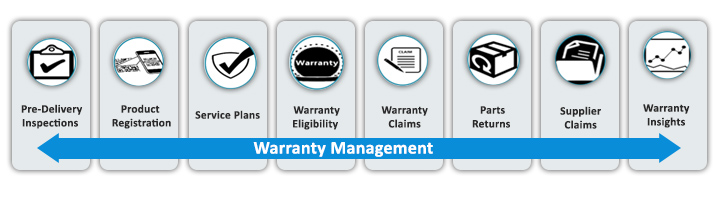

- What is the population that this data is measuring?
- What is not measured?

```r
set.seed(635)
warranty |>
  filter(Product_type == "TV") |>
  count(City, sort=TRUE) |>
  slice_sample(n=2)
```

```
# A tibble: 2 × 2
  City          n
  <chr>     <int>
1 Delhi       106
2 Bangalore   320
```

Can we say that Delhi has fewer problems with TVs than Bangalore?

[Source: ExcelR Projects. (2019). Warranty Claims. Kaggle.](https://www.kaggle.com/competitions/warranty-claims)

## 📋 Summary of checks for data collection

✅ Has the collection process been consistent?

✅ Does the set to be predicted match the training set?

✅ Is the experimental design correctly applied?

✅ Have treatments been appropriately *randomised* or assigned comprehensively across subjects?

✅ What is the population that the collected data describes?

✅ If the data is observational, can you group them into comparison sets?

## Imputing missing values

## Example 1: Olympic medals

```r
library(VGAM)
data(olym12)
olym12 |> select(country, totalmedal) |>
  arrange(desc(totalmedal))
```

```
             country totalmedal
1       UnitedStates        104
2              China         88
3             Russia         82
4       GreatBritain         65
5            Germany         44
6              Japan         38
7          Australia         35
8             France         34
9         SouthKorea         28
10             Italy         28
11       Netherlands         20
12           Ukraine         20
13            Canada         18
14           Hungary         17
```

[output cut: 71 more lines]

Is the average number of medals equal to 962/85 = 11.32?

What is missing?

What is the correct average number of medals?

962/204 = 4.72

Working out what is missing can be hard!

## Example 2: El Nino

Explore missings

- plotting on edge of plots, or
- using simple imputation like mean

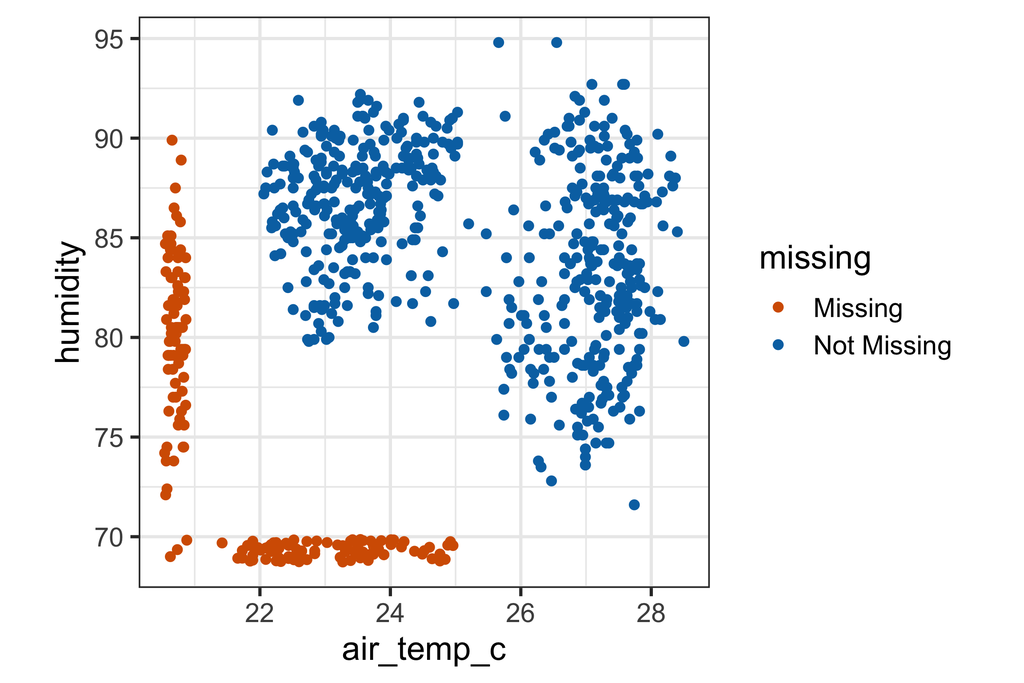

```r
oceanbuoys |>
  ggplot(aes(x=air_temp_c, y=humidity)) +
  geom_miss_point()
```

Impute and check

- Impute using regression or simulation
- Check distribution relative to complete cases

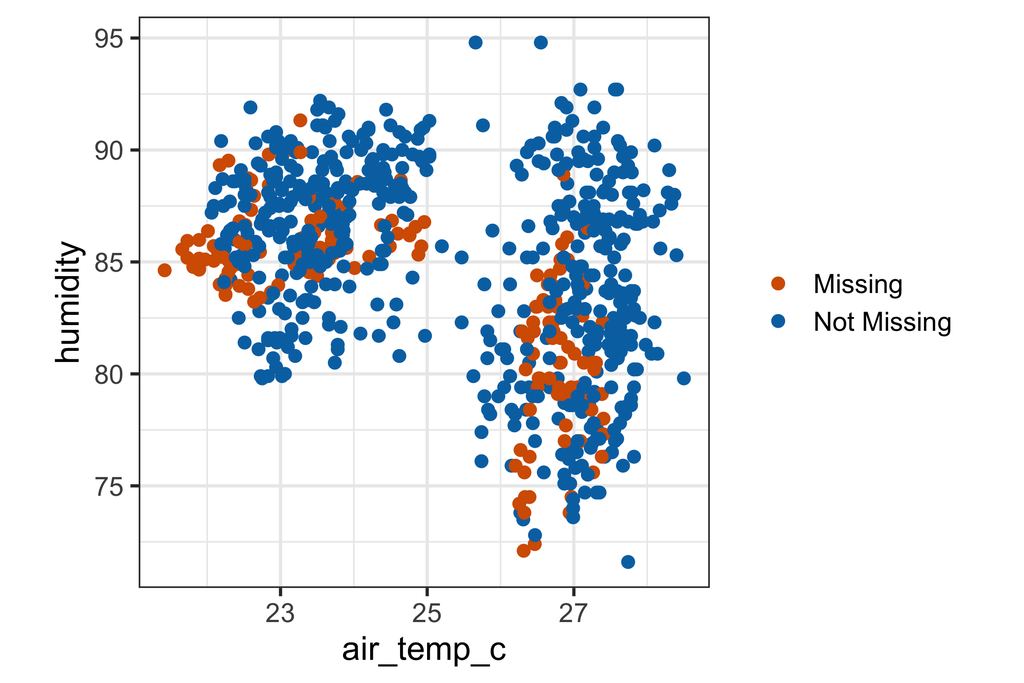

```r
library(simputation)
ocean_imp_yr <- oceanbuoys %>%
  bind_shadow() %>%
  impute_lm(air_temp_c ~ wind_ew + wind_ns + year + longitude + latitude) %>%
  impute_lm(humidity ~  wind_ew + wind_ns + year + longitude + latitude) %>%
  impute_lm(sea_temp_c ~  wind_ew + wind_ns + year + longitude + latitude) %>%
  add_label_shadow()

ggplot(ocean_imp_yr,
       aes(x = air_temp_c,
           y = humidity,
           color = any_missing)) +
  geom_point() +
  theme(legend.title = element_blank())
```

## Validators

Automating some checks

## Case study: Dutch supermarket revenue and cost (1/3)

- Data contains the revenue and cost (in Euros) for 60 supermarkets
- Data has been anonymised and distorted

```r
library(validate)
data("SBS2000", package = "validate")
dplyr::glimpse(SBS2000)
```

```
Rows: 60
Columns: 11
$ id          <fct> RET01, RET02, RET03, RET04, …
$ size        <fct> sc0, sc3, sc3, sc3, sc3, sc0…
$ incl.prob   <dbl> 0.02, 0.14, 0.14, 0.14, 0.14…
$ staff       <int> 75, 9, NA, NA, NA, 1, 5, 3, …
$ turnover    <int> NA, 1607, 6886, 3861, NA, 25…
$ other.rev   <int> NA, NA, -33, 13, 37, NA, NA,…
$ total.rev   <int> 1130, 1607, 6919, 3874, 5602…
$ staff.costs <int> NA, 131, 324, 290, 314, NA, …
$ total.costs <int> 18915, 1544, 6493, 3600, 553…
$ profit      <int> 20045, 63, 426, 274, 72, 3, …
$ vat         <int> NA, NA, NA, NA, NA, NA, 1346…
```

## Case study: Dutch supermarket revenue and cost (2/3)

- Checking for completeness of records

```r
rules <- validator(
          is_complete(id),
          is_complete(id, turnover),
          is_complete(id, turnover, profit))
out <- confront(SBS2000, rules)
summary(out)
```

```
  name items passes fails nNA error warning
1   V1    60     60     0   0 FALSE   FALSE
2   V2    60     56     4   0 FALSE   FALSE
3   V3    60     52     8   0 FALSE   FALSE
                         expression
1                   is_complete(id)
2         is_complete(id, turnover)
3 is_complete(id, turnover, profit)
```

## Case study: Dutch supermarket revenue and cost (3/3)

- Sanity check derived variables

```r
rules <- validator(
    total.rev - profit == total.costs,
    turnover + other.rev == total.rev,
    profit <= 0.6 * total.rev
)
out <- confront(SBS2000, rules)
summary(out)
```

```
  name items passes fails nNA error warning
1   V1    60     39    14   7 FALSE   FALSE
2   V2    60     19     4  37 FALSE   FALSE
3   V3    60     49     6   5 FALSE   FALSE
                                      expression
1 abs(total.rev - profit - total.costs) <= 1e-08
2 abs(turnover + other.rev - total.rev) <= 1e-08
3              profit - 0.6 * total.rev <= 1e-08
```

## IDA for hypothesis testing

## Hypothesis testing (1/3)

- State the hypothesis (pair), e.g. $H_o: \mu_1 = \mu_2$ vs $H_a: \mu_1 < \mu_2$.
- Test statistic depends on assumption about the distribution, e.g.
  - $t$-test will assume that distributions are *normal*, or small departures from if we have a large sample.
  - two-sample might assume both groups have the *same variance*
- Steps to complete:
  - Compute the test statistic
  - Measure it against a standard distribution
  - If it is extreme, $p$-value is small, decision is to reject $H_o$
  - $p$-value is the probability of observing a value as large as this, or large, assuming $H_o$ is true.

## Example 1: Checking variance and distribution (2/3)

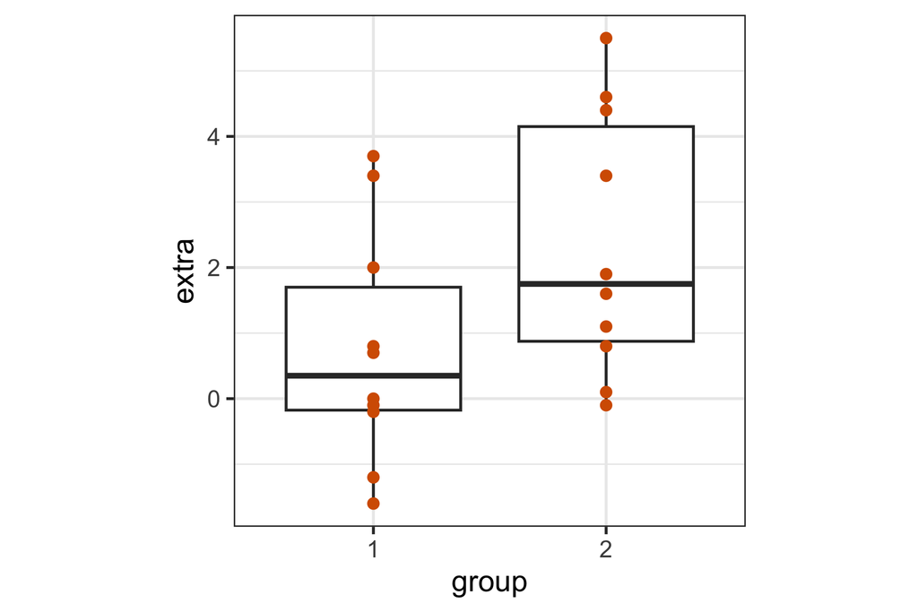

```r
data(sleep)
ggplot(sleep, aes(x=group, y=extra)) +
  geom_boxplot() +
  geom_point(colour="#D55E00")
```

Cushny, A. R. and Peebles, A. R. (1905) The action of optical isomers: II hyoscines. The Journal of Physiology 32, 501–510.

Few observations. Nothing strongly suggests violation of normality and spread of points is similar for each group.

```r
tt <- with(sleep,
     t.test(extra[group == 1],
            extra[group == 2],
            paired = TRUE))
tt
```

```
    Paired t-test

data:  extra[group == 1] and extra[group == 2]
t = -4, df = 9, p-value = 0.003
alternative hypothesis: true mean difference is not equal to 0
95 percent confidence interval:
 -2.5 -0.7
sample estimates:
mean difference
           -1.6
```

## Example 2: Checking distribution and variance (3/3)

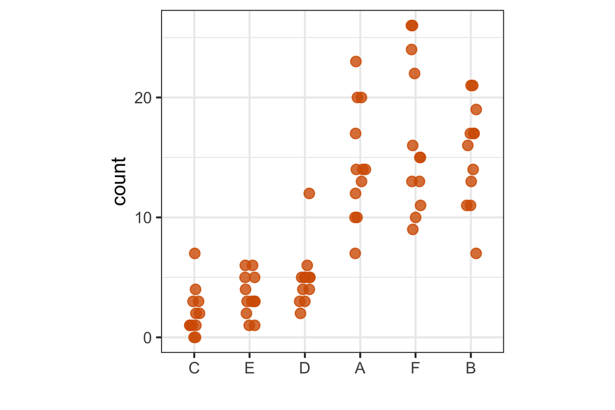

```r
InsectSprays  |>
  ggplot(aes(x=fct_reorder(spray, count),
             y=count)) +
  geom_jitter(width=0.1, height=0, colour="#D55E00", size=3, alpha=0.8) +
  xlab("")
```

Is it plausible that the samples are from a normal population? Do they have equal variance?

```r
fm1 <- aov(count ~ spray, data = InsectSprays)
summary(fm1)
```

```
            Df Sum Sq Mean Sq F value Pr(>F)
spray        5   2669     534    34.7 <2e-16 ***
Residuals   66   1015      15
---
Signif. codes:
0 '***' 0.001 '**' 0.01 '*' 0.05 '.' 0.1 ' ' 1
```

What hypothesis being tested? What would the decision be?

Why does equal variance matter in this test?

## Summary

> *The Census Bureau tabulates same-sex couples in both the American Community Survey (ACS) and the Decennial Census. Two questions are used to identify same-sex couples: relationship and sex. The agency follows edit rules that are used to change data values for seemingly contradictory answers. The edit rules for combining information from relationship and sex have evolved since the category of unmarried partner was added in 1990. In that census, if a household consisted of a married couple and both spouses reported the same sex, the relationship category remained husband or wife, but the sex of the partner who reported being a spouse to the householder was changed.* [Humans all the way down](https://theory4ida.github.io/tmcf/posts/03-cultures/)

Human actions are ubiquitous in every part of data analysis! The most objective methods often have had subjective actions before and after.

## Data quality check list

**Completeness**

- Check for missing values, and whether random or systematic
- Check for missing records entirely (e.g., expected rows/groups that don’t appear)
- Verify no truncated or incomplete data pulls (e.g., API/export cut off early)

**Accuracy & validity**

- Check for suspicious patterns (e.g., too many identical values, default/placeholder values like 9999 or “N/A” strings)
- Check values fall within expected ranges (e.g., age isn’t negative or 200)
- Validate categorical variables against expected category lists (no typos/variants like “NY” vs “New York” vs “ny”)
- Check date fields are valid and logically ordered (e.g., start date before end date)

**Consistency**

- Check for duplicate records (exact and near-duplicates)
- Verify consistent formatting (date formats, units of measurement, capitalization)
- Check consistent coding across related variables (e.g., same ID format across joined tables)
- Confirm consistent granularity (e.g., not mixing daily and monthly records unintentionally)

**Structural integrity**

- Confirm column data types match expectations (no numbers stored as text, etc.)
- Check for structural issues from import (shifted columns, broken delimiters, encoding issues)
- Verify referential integrity between related tables (foreign keys match)

### Data quality check list

**Uniqueness**

- Verify primary keys/IDs are actually unique
- Check for unintended many-to-many joins when merging datasets

**Timeliness**

- Confirm data reflects the relevant/expected time period
- Check for stale or outdated records if freshness matters

**Documentation & provenance**

- Confirm data source and collection method are known
- Check for a data dictionary/metadata describing variables
- Note any known transformations already applied to the data

### Check list for statistical assumptions

- Identify (statistical) outliers (z-score, IQR method), data errors or genuine extreme values
- Univariate distributions are reasonably spread, not skewed or multimodal, or are transformations needed
- Outcome variable could reasonably support normal error distribution
- Are observations independently sampled?
- Do outcome and continuous predictors have a linear relationship?
- Is the relationship between outcome and predictors homoscedastic?
- Are predictors not associated?
- Are training and test sets similar?
- For categorical variables, do all levels have sufficient sample size?

## Resources

- Huebner et al (2018) [A Contemporary Conceptual Framework for Initial Data Analysis](https://muse.jhu.edu/article/793379/pdf)
- Huebner et al (2020) [Hidden analyses](https://bmcmedresmethodol.biomedcentral.com/articles/10.1186/s12874-020-00942-y)
- Chatfield (1985) The Initial Examination of Data. *Journal of the Royal Statistical Society. Series A (General)* **148**
- Cox & Snell (1981) Applied Statistics. *London: Chapman and Hall.*
- van der Loo and de Jonge (2018). Statistical Data Cleaning with Applications in R. John Wiley and Sons Ltd.
- Hyndman (2014) [Explaining the ABS unemployment fluctuations](https://robjhyndman.com/hyndsight/abs-seasonal-adjustment-2/)